# How to use the NetworkExtinction Package

M.Isidora Avila-Thieme, Derek Corcoran, and Erik Kusch

2023-03-31

# Introduction

The objectives of the *NetworkExtinction* package is to analyse and visualize the topology of ecological networks and its responses to the simulated extinction of species.

**NetworkExtinction** has been conceptualised for **trophic** and **mutualistic** ecological networks. The network type needs to be declared to functions of the R package with the `NetworkType` argument.

The main indexes used for these analyses are:

1. Number of nodes: Total number of species in the network (Dunne, Williams, and Martinez 2002).
2. Number of links: Number of trophic relationships represented in the food web (Dunne, Williams, and Martinez 2002).
3. Connectance: Proportion of all possible trophic links that are completed (Dunne, Williams, and Martinez 2002).
4. Primary removals: It occurs when the researcher intentionally removes one species, simulating a single extinction.
5. Secondary extinctions: A secondary extinction occurs when a non basal species loses all of its prey items due to the removal of another species. In this context, basal species can experience primary removal, but not secondary extinctions (Dunne, Williams, and Martinez 2002).
6. Total extinctions: The sum of primary removal and secondary extinctions in one simulation.

Functions to analyse the cascading effect of extinctions are the following:

- *SimulateExtinctions:* To simulate extinctions from the most connected species to less connected in the network, or in a customized order.
- *RandomExtinctions:* To develop a null hypothesis by generating random orders of simulated extinctions.
- *CompareExtinctions:* To compare the observed secondary extinctions with the expected secondary extinction generated by random extinction.

The function to plot results is:

- *ExtinctionPlot:* To plot the results of any of the extinction functions

The function to analyse the degree distribution is:

- *DegreeDistribution:* To test if the degrees in the network follow a power law, or exponential.

## How to install the package

As any package in cran the *install.packages* function can be used to install the *NetworkExtinction* package as shown in the following code.

```r
install.packages(NetworkExtinction)
library(NetworkExtinction)
```

or install the most recent

```r
devtools::install_github("derek-corcoran-barrios/NetworkExtintion")
```

## How to represent a food web in R

The first step to make any analysis in the *NetworkExtinction* package is to build a representation of a food web.

The NetworkExtinction package accepts a matrix, an edgelist or a Network build in the network package (Butts et al. 2008).

As an example of how to build a food web we will explain how to create the network shown in figure 1.

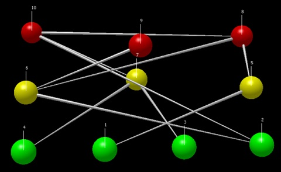

Figure 1. Food-web to be contructed in R

This network has ten nodes where each node represents one species. Here, four nodes are basal species (primary producers, from sp.1 to sp.4), three nodes are intermediate (primary consumers, from sp.5 to sp.7), and the remaining three are top predators (from sp.8 to sp.10).

In order to build an interaction matrix (Figure 2) that represent the food web, we create a square matrix with a column and a row representing each species. Columns represent the consumers and the rows the resources, where 1 represents a trophic interaction and 0 its absence. Note that in the columns, the first four species only have zeros because they are not consumers. For example, if we look at species 7, it feeds on species 4 and 3. In order to represent that, we would go to column 7 and put a 1 in rows 3 and 4.

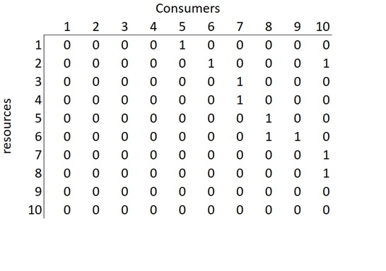

Figure 2. Matrix representation of the food web

The following code is an example of how to build the matrix in figure 2 using R:

```r
a<- matrix(c(0, 0, 0, 0, 0, 0, 0, 0, 0, 0, 0, 0, 0, 0, 0, 0, 0, 0, 0, 0, 0, 0, 0, 0, 0, 0, 0, 0, 0, 0, 0, 0, 0, 0, 0, 0, 0, 0, 0, 0, 1, 0, 0, 0, 0, 0, 0, 0, 0, 0, 0, 1, 0, 0, 0, 0, 0, 0, 0, 0, 0, 0, 1, 1, 0, 0, 0, 0, 0, 0, 0, 0, 0, 0, 1, 1, 0, 0, 0, 0, 0, 0, 0, 0, 0, 1, 0, 0, 0, 0, 0, 1, 0, 0, 0, 0, 1, 1, 0, 0),nrow=10, ncol=10)

a
```

```
#>       [,1] [,2] [,3] [,4] [,5] [,6] [,7] [,8] [,9] [,10]
#>  [1,]    0    0    0    0    1    0    0    0    0     0
#>  [2,]    0    0    0    0    0    1    0    0    0     1
#>  [3,]    0    0    0    0    0    0    1    0    0     0
#>  [4,]    0    0    0    0    0    0    1    0    0     0
#>  [5,]    0    0    0    0    0    0    0    1    0     0
#>  [6,]    0    0    0    0    0    0    0    1    1     0
#>  [7,]    0    0    0    0    0    0    0    0    0     1
#>  [8,]    0    0    0    0    0    0    0    0    0     1
#>  [9,]    0    0    0    0    0    0    0    0    0     0
#> [10,]    0    0    0    0    0    0    0    0    0     0
```

Once the matrix is ready, we use the *as.network* function from the *network* package to build a network object.

```r
library(network)
net <- as.network(a, loops = TRUE)
net
```

```
#>  Network attributes:
#>   vertices = 10
#>   directed = TRUE
#>   hyper = FALSE
#>   loops = TRUE
#>   multiple = FALSE
#>   bipartite = FALSE
#>   total edges= 10
#>     missing edges= 0
#>     non-missing edges= 10
#>
#>  Vertex attribute names:
#>     vertex.names
#>
#> No edge attributes
```

# Functions

## Extinctions functions

### Extinctions from most to less conected species in the network

The `Mostconnected()` function sorts the species from the most connected node to the least connected node, using total degree. Then, it removes the most connected node in the network, simulating its extinction, and recalculates the topological indexes of the network and counts how many species have indegree 0 (secondary extinction), not considering primary producers. Then, it removes the nodes that were secondarily extinct in the previous step and recalculates which node is the new most connected species. This step is repeated until the number of links in the network is zero (Sole and Montoya 2001; Dunne, Williams, and Martinez 2002; Dunne and Williams 2009).

```r
library(NetworkExtinction)
data("net")
SimulateExtinctions(Network = net, Method = "Mostconnected")
```

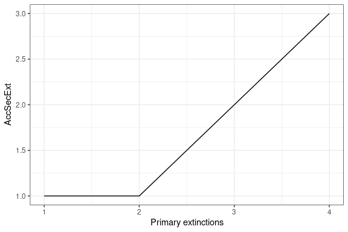

Figure 3. The graph shows the number of accumulated secondary extinctions that occur when removing species from the most to the least connected species

```r
data("More_Connected")
history <- SimulateExtinctions(Network = net, Method = "Mostconnected")
ExtinctionPlot(History = history[[1]], Variable = "AccSecExt")
```

### Extinctions using a customized order

The `ExtinctionOrder()` function takes a network and extinguishes nodes using a customized order. Then, it calculates the topological network indexes and the secondary extinctions. In our toy network, nodes 1-4 are primary producers while nodes 9 and 10 represent apex predators. Let’s see what happens when we sequentially remove all but the apex predators:

```r
data("net")
SimulateExtinctions(Network = net, Order = 1:8, Method = "Ordered")
```

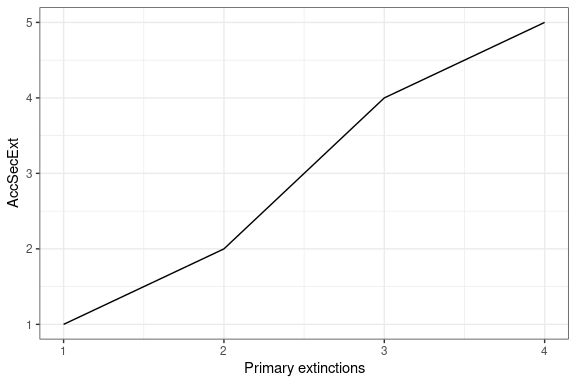

Figure 4. The graph shows the number of accumulated secondary extinctions that occur when removing species in a custom order.

### Random extinction

```r
data(net)
set.seed(707)
RandomExtinctions(Network= net, nsim= 100, SimNum = 8)
```

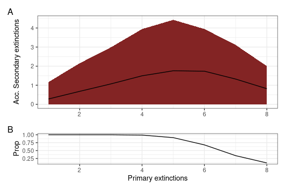

Figure 5. The resulting graph of the RandomExtinctions function

### Comparison of Null hypothesis with other extinction histories

The `RandomExtinctons()` function generates a null hypothesis for us to compare it with either an extinction history generated by the `ExtinctionOrder()` function or the `Mostconnected()` function. In order to compare the expected extinctions developed by our null hypothesis with the observed extinction history, we developed the `CompareExtinctions()` function. The way to use this last function is to first create the extinction history and the null hypothesis, and then the `CompareExtinctions()` function to compare both extinction histories.

```r
data("net")
Comparison <- CompareExtinctions(Nullmodel = Test, Hypothesis = Order)
```

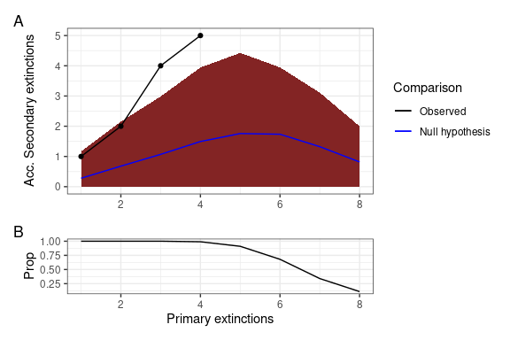

## Plotting the extinction histories of a network

The `ExtinctionPlot()` function takes a NetworkTopology class object and plots the index of interest after every extinction. By default, the function plots the number of accumulated secondary extinctions after every primary extinction (Figure 7), but any of the indexes can be plotted with the function by changing the Variable argument (Figure 8).

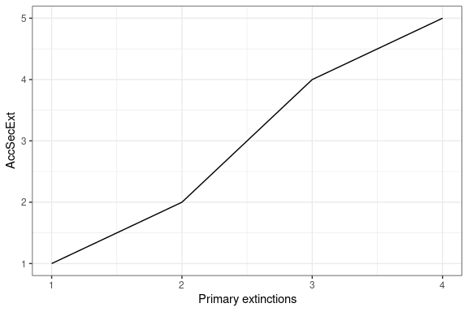

Figure 7. Example of the use of the ExtinctionPlot function showing the accumulated secondary extinctions against number of extinctions

```r
data(net)
ExtinctionPlot(History = Order[[1]])
```

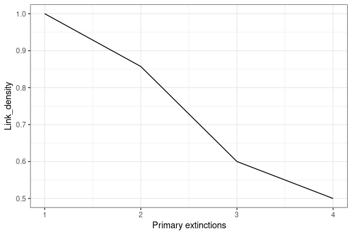

Figure 8. Another example of the use of the ExtinctionPlot function showing the number of links per species against number of extinctions

```r
ExtinctionPlot(History = Order[[1]], Variable = "Link_density")
```

## Degree distribution function

The `DegreeDistribution()` function calculates the cumulative distribution of the number of links that each species in the food network has (Estrada 2007). Then, the observed distribution is fitted to the exponential, and power law models.

```r
data("chilean_intertidal")
DegreeDistribution(chilean_intertidal)
```

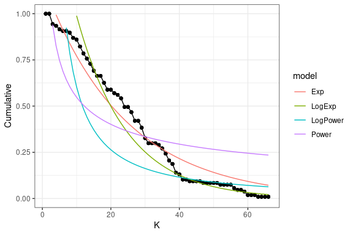

Table 4: Model selection analysis

| logLik | AIC | BIC | model | Normal.Resid | family |
| --- | --- | --- | --- | --- | --- |
| 83.14753 | -160.29506 | -153.63654 | Exp | No | Exponential |
| 13.38647 | -20.77293 | -14.20397 | Power | No | PowerLaw |
| -27.48222 | 60.96444 | 67.53341 | LogExp | No | Exponential |
| -80.84172 | 167.68343 | 174.25240 | LogPower | No | PowerLaw |

The main objective of fitting the cumulative distribution of the degrees to those models, is to determine if the vulnerability of the network to the removal of the most connected species is related to their degree distribution. Networks that follow a power law distribution are very vulnerable to the removal of the most connected nodes, while networks that follow exponential degree distribution are less vulnerable to the removal of the most connected nodes (Albert and Barabási 2002; Dunne, Williams, and Martinez 2002; Estrada 2007; Santana et al. 2013).

# Inter-Network Dependendancy

By default, the functions in *NetworkExtinction* assume that, for a secondary extinction to happen, a node needs to loose all connections to its prey (if `NetworkType == "Trophic"`) or all other nodes (if `NetworkType == "Mutualistic"`).

One may also want to assume that species are only capable of sustaining existence given a threshold of remaining interaction strengths. This is implemented with the `IS` argument, with which one can either set a global node-dependency on interaction strengths or, alternatively, define an `IS` value for each node in the supplied network.

As a minimal example, let’s consider primary extinctions of two of the producers in our toy network not taking into account any interaction strength loss thresholds:

```r
IS_0 <- SimulateExtinctions(Network = net, Order = 1:2, Method = "Ordered")[[1]]
```

Table 5: The resulting dataframe of the basic version of SimulateExtinctions

| Spp | S | L | C | Link_density | Modularity | SecExt | Pred_release | Iso_nodes | AccSecExt | NumExt | TotalExt |
| --- | --- | --- | --- | --- | --- | --- | --- | --- | --- | --- | --- |
| 1 | 9 | 9 | 0.1111111 | 1.0000000 | 0.2901235 | 1 | 0 | 0 | 1 | 1 | 2 |
| 2 | 7 | 6 | 0.1224490 | 0.8571429 | 0.0000000 | 1 | 0 | 0 | 2 | 2 | 4 |

As you can see, with the base version of `SimulateExtinctions()`, we obtain two secondary extinctions.

Now, let’s consider that all our species in `net` need to retain a minimum of 70% of interaction strength to not go extinct (rather than a 0% as is the default):

```r
IS_0.7 <- SimulateExtinctions(Network = net, Order = 1:2, Method = "Ordered", IS = 0.7)[[1]]
```

Table 6: The resulting dataframe of the interaction-strength loss version of SimulateExtinctions

| Spp | S | L | C | Link_density | Modularity | SecExt | Pred_release | Iso_nodes | AccSecExt | NumExt | TotalExt |
| --- | --- | --- | --- | --- | --- | --- | --- | --- | --- | --- | --- |
| 1 | 9 | 9 | 0.1111111 | 1.0000000 | 0.2901235 | 1 | 1 | 0 | 1 | 1 | 2 |
| 2 | 7 | 6 | 0.1224490 | 0.8571429 | 0.0000000 | 3 | 2 | 0 | 4 | 2 | 6 |

As you can see, this drastically changes how many secondary extinctions we estimate.

# Rewiring Potential

Ecological networks aren’t static and we should assume that species may shift their connections in response to extinctions of an association/interaction partner. Rewiring processes can be simulated with *NetworkExtinction* using the `Rewiring`, `RewiringDist`, and `RewiringProb` arguments.

Let’s start with `RewiringDist`. This should be a matrix that contains information about similarities or rewiring potential of species indexed by columns to those indexed by rows. The package comes with an example data set for this:

```r
data(dist)
dist
```

```
#>             1         2          3          4         5         6         7
#> 1  0.00000000 0.4593111 0.10593644 0.30189790 0.4705959 0.1783138 0.4530299
#> 2  0.45931109 0.0000000 0.56524753 0.76120899 0.8902942 0.5980121 0.8727282
#> 3  0.10593644 0.5652475 0.00000000 0.19596146 0.5765323 0.2842503 0.5589664
#> 4  0.30189790 0.7612090 0.19596146 0.00000000 0.7724938 0.4802117 0.7549278
#> 5  0.47059588 0.8902942 0.57653232 0.77249378 0.0000000 0.2922820 0.5669981
#> 6  0.17831383 0.5980121 0.28425027 0.48021173 0.2922820 0.0000000 0.2747161
#> 7  0.45302992 0.8727282 0.55896636 0.75492782 0.5669981 0.2747161 0.0000000
#> 8  0.20346538 0.6627765 0.09752893 0.09843253 0.6740613 0.3817792 0.6564953
#> 9  0.01647744 0.4428337 0.12241388 0.31837534 0.4870733 0.1947913 0.4695074
#> 10 0.54697008 0.4174089 0.44103364 0.63699510 0.5059987 0.7252839 1.0000000
#>             8          9        10
#> 1  0.20346538 0.01647744 0.5469701
#> 2  0.66277647 0.44283365 0.4174089
#> 3  0.09752893 0.12241388 0.4410336
#> 4  0.09843253 0.31837534 0.6369951
#> 5  0.67406125 0.48707331 0.5059987
#> 6  0.38177920 0.19479127 0.7252839
#> 7  0.65649529 0.46950735 1.0000000
#> 8  0.00000000 0.21994281 0.5385626
#> 9  0.21994281 0.00000000 0.5634475
#> 10 0.53856257 0.56344752 0.0000000
```

This is a random distance matrix. For the sake of this example, we assume that these values represent probabilities of rewiring. We have to tweak it a bit to make it useful for our toy example of a trophic network, we do so by setting some of the values to 0:

```r
dist[,1:4] <- 0 # producers don't worry about rewiring
dist[5:10,5:8] <- 0 # intermediate consumders can only rewire to producers
dist[c(1:4, 9:10), 9:10] <- 0 # apex predators can only rewire to intermediate consumers
dist
```

```
#>    1 2 3 4         5         6         7          8         9        10
#> 1  0 0 0 0 0.4705959 0.1783138 0.4530299 0.20346538 0.0000000 0.0000000
#> 2  0 0 0 0 0.8902942 0.5980121 0.8727282 0.66277647 0.0000000 0.0000000
#> 3  0 0 0 0 0.5765323 0.2842503 0.5589664 0.09752893 0.0000000 0.0000000
#> 4  0 0 0 0 0.7724938 0.4802117 0.7549278 0.09843253 0.0000000 0.0000000
#> 5  0 0 0 0 0.0000000 0.0000000 0.0000000 0.00000000 0.4870733 0.5059987
#> 6  0 0 0 0 0.0000000 0.0000000 0.0000000 0.00000000 0.1947913 0.7252839
#> 7  0 0 0 0 0.0000000 0.0000000 0.0000000 0.00000000 0.4695074 1.0000000
#> 8  0 0 0 0 0.0000000 0.0000000 0.0000000 0.00000000 0.2199428 0.5385626
#> 9  0 0 0 0 0.0000000 0.0000000 0.0000000 0.00000000 0.0000000 0.0000000
#> 10 0 0 0 0 0.0000000 0.0000000 0.0000000 0.00000000 0.0000000 0.0000000
```

This matrix makes a lot more sense for our purposes. To clarify once more how to read this data: species 8 (column) has a $.663$ chance of rewiring to species 2 (row).

Next, `Rewiring` is a function argument that, just like the `IS` argument can be set globally or individually for each node. It is used to calculate probabilities of rewiring from the data in `RewiringDist`. Since we assume `RewiringDist` to already contain probabilities in this example, we simply set `RewiringDist` to return the data without changing it:

```r
RewiringDist <- function(x){x}
```

Lastly, `RewiringProb` is called upon to determine whether rewiring can happen among all potential rewiring partners. If no potential rewiring partner comes with a probability higher than this threshold, no rewiring happens. If multiple potential partners meet this threshold, rewiring happens only to the potential partner with the highest probability. Let’s keep the default of 50% here.

Finally, let’s out this all together with the `IS` example from above. Can we reduce the number of secondary extinctions when allowing for rewiring?

```r
Rewiring <- SimulateExtinctions(Network = net, Order = 1:2, Method = "Ordered", IS = 0.7,
                              Rewiring = function(x){x}, RewiringDist = dist, RewiringProb = 0.5)[[1]]
```

Table 7: The resulting dataframe of the rewiring version of SimulateExtinctions

| Spp | S | L | C | Link_density | Modularity | SecExt | Pred_release | Iso_nodes | AccSecExt | NumExt | TotalExt |
| --- | --- | --- | --- | --- | --- | --- | --- | --- | --- | --- | --- |
| 1 | 9 | 9 | 0.1111111 | 1.000 | 0.2901235 | 0 | 0 | 0 | 0 | 1 | 1 |
| 2 | 8 | 7 | 0.1250000 | 0.875 | 0.3571429 | 1 | 1 | 0 | 1 | 2 | 3 |

# Bibliography

Albert, Réka, and Albert-László Barabási. 2002. “Statistical Mechanics of Complex Networks.” *Reviews of Modern Physics* 74 (1): 47.

Butts, Carter T et al. 2008. “Network: A Package for Managing Relational Data in r.” *Journal of Statistical Software* 24 (2): 1–36.

Dunne, Jennifer A, and Richard J Williams. 2009. “Cascading Extinctions and Community Collapse in Model Food Webs.” *Philosophical Transactions of the Royal Society B: Biological Sciences* 364 (1524): 1711–23.

Dunne, Jennifer A, Richard J Williams, and Neo D Martinez. 2002. “Food-Web Structure and Network Theory: The Role of Connectance and Size.” *Proceedings of the National Academy of Sciences* 99 (20): 12917–22.

Estrada, Ernesto. 2007. “Food Webs Robustness to Biodiversity Loss: The Roles of Connectance, Expansibility and Degree Distribution.” *Journal of Theoretical Biology* 244 (2): 296–307.

Kéfi, Sonia, Eric L Berlow, Evie A Wieters, Lucas N Joppa, Spencer A Wood, Ulrich Brose, and Sergio A Navarrete. 2015. “Network Structure Beyond Food Webs: Mapping Non-Trophic and Trophic Interactions on Chilean Rocky Shores.” *Ecology* 96 (1): 291–303.

Santana, Charles N de, Alejandro F Rozenfeld, Pablo A Marquet, and Carlos M Duarte. 2013. “Topological Properties of Polar Food Webs.” *Marine Ecology Progress Series* 474: 15–26.

Sole, Ricard V, and M Montoya. 2001. “Complexity and Fragility in Ecological Networks.” *Proceedings of the Royal Society of London B: Biological Sciences* 268 (1480): 2039–45.